# Twitter hashtag analysis: #schoolstrike4climate

Ben Anderson (`@dataknut`)

Last run at: 2019-03-14 08:20:06 (Europe/London)

# 1 Terms of re-use

## 1.1 License

[CC-BY-SA](https://creativecommons.org/licenses/by-sa/4.0/) unless otherwise noted.

## 1.2 Citation

- Anderson, B (2019) *Twitter hashtag analysis: #schoolstrike4climate*. Downloaded from: https://dataknut.github.io/hashTagR//home/ba1e12/github/dataknut/hashTagR/docs/schoolstrike4climate.html.

# 2 Purpose

Why? Err…. Just. Because.

# 3 How it works

Code borrows extensively from https://github.com/mkearney/rtweet

The analysis used `rtweet` to ask the Twitter search API to extract ‘all’ tweets containing the *#schoolstrike4climate* hashtags in the ‘[recent](https://developer.twitter.com/en/docs/tweets/search/api-reference/get-search-tweets)’ twitterVerse.

It is therefore possible that not quite all tweets have been extracted although it seems likely that we have captured most recent `human` tweeting which was the main intention. Future work should instead use the Twitter [streaming API](https://dev.twitter.com/streaming/overview).

```
## [1] "Found 1 files matching #schoolstrike4climate in ~/Data/twitter/"
```

The data has:

- 17,995 tweets (including 474 quotes and 16,369 re-tweets)
- from 11,915 tweeters
- between 2019-03-10 19:15:20 and 2019-03-14 08:10:59 (UTC).

# 4 Analysis

## 4.1 Tweets and Tweeters over time

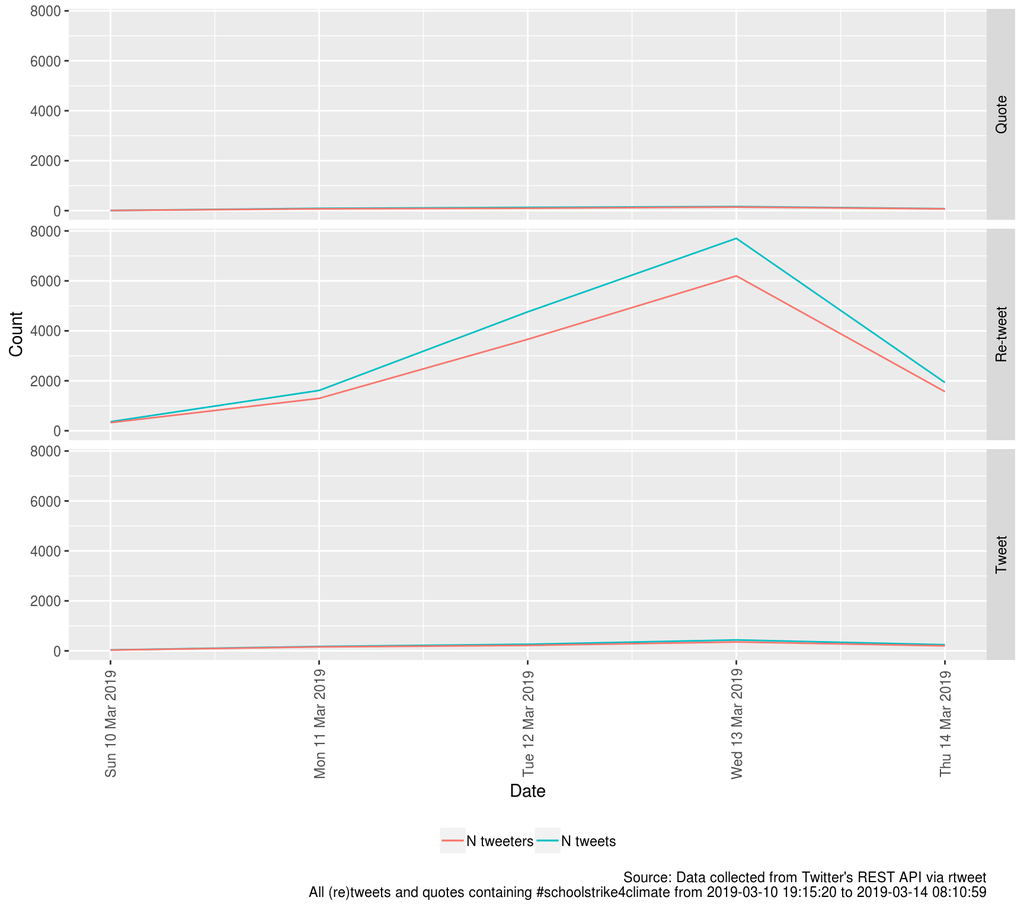

Figure 4.1: Number of tweets and tweeters

Figure 4.1 shows the number of tweets and tweeters in the data extract by day. The quotes, tweets and re-tweets have been separated.

If you are in New Zealand and you are wondering why there are no tweets `today` (2019-03-14) the answer is that twitter data (and these plots) are working in UTC and (y)our `today()` may not have started yet in UTC. Don’t worry, all the tweets are here - it’s just our old friend the timezone… :-)

## 4.2 Who’s tweeting?

Next we’ll try by screen name.

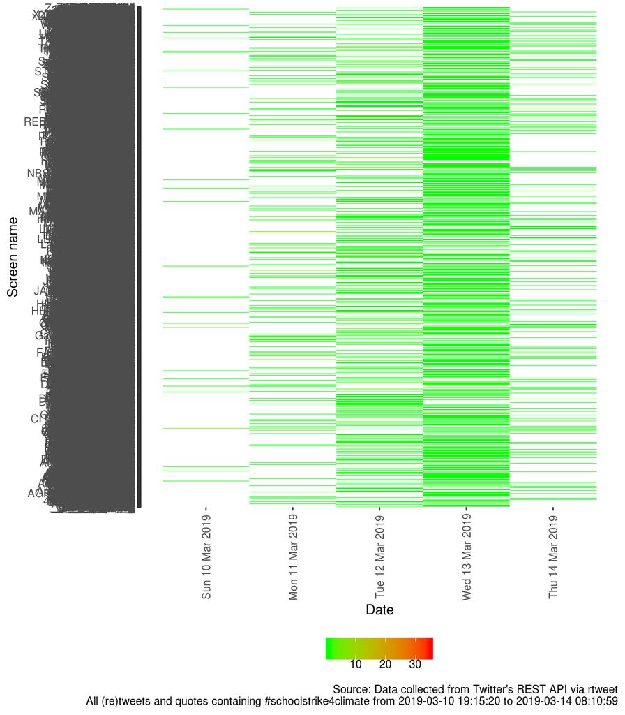

Figure 4.2: N tweets per day by screen name

Figure 4.2 is a really bad visualisation of all tweeters tweeting over time. Each row of pixels is a tweeter (the names are probably illegible) and a green dot indicates a few tweets in the given day while a red dot indicates a lot of tweets.

So let’s re-do that for the top 50 tweeters so we can see their tweetStreaks (tm)…

Top tweeters:

Table 4.1: Top 15 tweeters (all days)

| screen_name | nTweets |
| --- | --- |
| NoahsArkCrew | 101 |
| Glo_man | 49 |
| GreenpeaceNZ | 37 |
| heidi_k_edmonds | 33 |
| 5Explorer | 32 |
| Beccabluesky | 31 |
| daniel_scholler | 27 |
| DormouseRoared | 24 |
| GreenNewDeal_EU | 22 |
| kiki_viola8 | 22 |
| Amoghashiddi | 21 |
| 64by4 | 21 |
| xida2001 | 20 |
| SchoolCO2lution | 20 |
| GillKing01 | 20 |

And their tweetStreaks are shown in Figure 4.3…

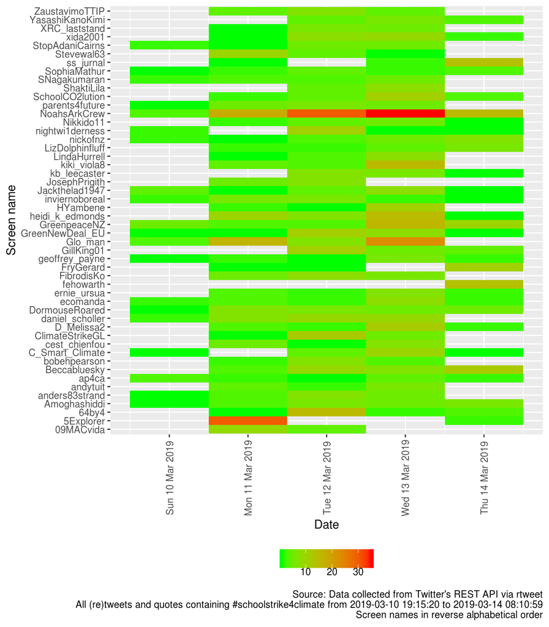

Figure 4.3: N tweets per day minutes by screen name (top 50, reverse alphabetical)

Any twitterBots…?

# 5 About

Analysis completed in 21.596 seconds ( 0.36 minutes) using knitr in [RStudio](http://www.rstudio.com) with R version 3.5.1 (2018-07-02) running on x86_64-redhat-linux-gnu.

Other R packages used:

# References

Dowle, M, A Srinivasan, T Short, S Lianoglou with contributions from R Saporta, and E Antonyan. 2015. *Data.table: Extension of Data.frame*. https://CRAN.R-project.org/package=data.table.

R Core Team. 2016. *R: A Language and Environment for Statistical Computing*. Vienna, Austria: R Foundation for Statistical Computing. https://www.R-project.org/.

Wickham, Hadley. 2009. *Ggplot2: Elegant Graphics for Data Analysis*. Springer-Verlag New York. http://ggplot2.org.

———. 2016. *Stringr: Simple, Consistent Wrappers for Common String Operations*. https://CRAN.R-project.org/package=stringr.

Wickham, Hadley, Jim Hester, and Romain Francois. 2016. *Readr: Read Tabular Data*. https://CRAN.R-project.org/package=readr.

Xie, Yihui. 2016. *Knitr: A General-Purpose Package for Dynamic Report Generation in R*. https://CRAN.R-project.org/package=knitr.